# Logistic Regression

2018-01-23

# Binary responses

```r
library(faraway)
data(wcgs)
summary(wcgs)
```

```
      age            height          weight         sdp
 Min.   :39.00   Min.   :60.00   Min.   : 78   Min.   : 98.0
 1st Qu.:42.00   1st Qu.:68.00   1st Qu.:155   1st Qu.:120.0
 Median :45.00   Median :70.00   Median :170   Median :126.0
 Mean   :46.28   Mean   :69.78   Mean   :170   Mean   :128.6
 3rd Qu.:50.00   3rd Qu.:72.00   3rd Qu.:182   3rd Qu.:136.0
 Max.   :59.00   Max.   :78.00   Max.   :320   Max.   :230.0

      dbp              chol       behave         cigs      dibep
 Min.   : 58.00   Min.   :103.0   A1: 264   Min.   : 0.0   A:1565
 1st Qu.: 76.00   1st Qu.:197.2   A2:1325   1st Qu.: 0.0   B:1589
 Median : 80.00   Median :223.0   B3:1216   Median : 0.0
 Mean   : 82.02   Mean   :226.4   B4: 349   Mean   :11.6
 3rd Qu.: 86.00   3rd Qu.:253.0             3rd Qu.:20.0
 Max.   :150.00   Max.   :645.0             Max.   :99.0
                  NA's   :12
  chd           typechd        timechd         arcus
 no :2897   angina  :  51   Min.   :  18   absent :2211
 yes: 257   infdeath: 135   1st Qu.:2842   present: 941
            none    :2897   Median :2942   NA's   :   2
            silent  :  71   Mean   :2684
                            3rd Qu.:3037
                            Max.   :3430
```

Response is `chd`, coronary heart disease (yes or no)

Goal:

- Model relationship between response and predictors
- Predict response (binary—success or failure)
- Model probability of success or failure
- $P(Y_i = 1) = p_i$
- Model $p_i = x_i^T \beta$ does not work

Try:

- $\eta_i = x_i^t \beta$
- $\eta_i$ uses a linear predictor—need to transform to $(0, 1)$
- $\eta_i = g(p_i)$ where $p_i = P(Y_i = 1)$
  - $g$ needs to be monotone
  - $0 \leq g^{-1}(\eta) \leq 1$
- logit function $\eta = log(\frac{p}{1-p})$
- inverse logit $p_i = \frac{e^\eta}{1 + e^\eta} = \frac{1}{1 + e^{-\eta}}$

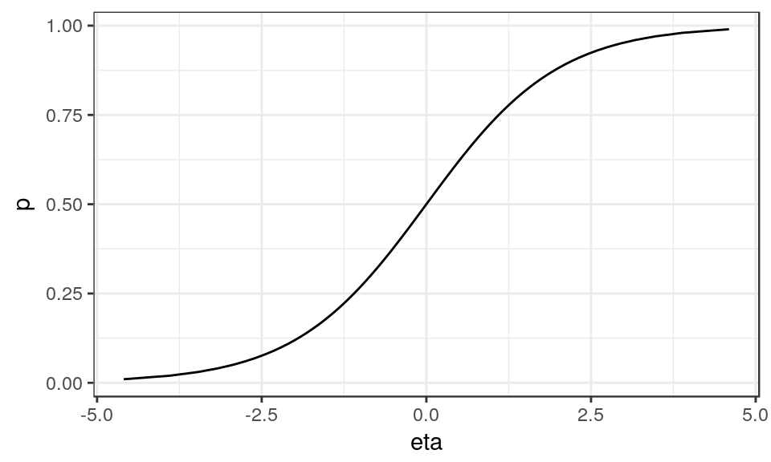

### Maximum likelihood estimator

**def** *likelihood*

$$L(\beta) = \prod_i^n P(Y_i = 1)$$

And by Bernoulli:

$$P(Y_i = 1) = p_i^{y_i} (1 - p_i)^{1 - y_i}$$

Note that

- $y_i = 1 \implies P(Y_i = 1) = p_i$
- $y_i = 0 \implies P(Y_i = 0) = 1 - p_i$

Then

$$\log(L(\beta)) = l(\beta) = \sum_i^n \log(p_i^{y_i} (1 - p_i)^{1 - y_i})$$
$$l(\beta) = \sum_i \big( y_i \log p_i + (1 - y_i) \log(1 - p_i) \big)$$

$$= \sum_i \big( y_i \log(\frac{p_i}{1 - p_i}) + \log(1 - p_i) \big)$$
$$= \sum_i y_i \eta_i - \log(e^{\eta_i} + 1)$$

So we want to maximize $l(\beta)$ to otain the MLE of $\beta$

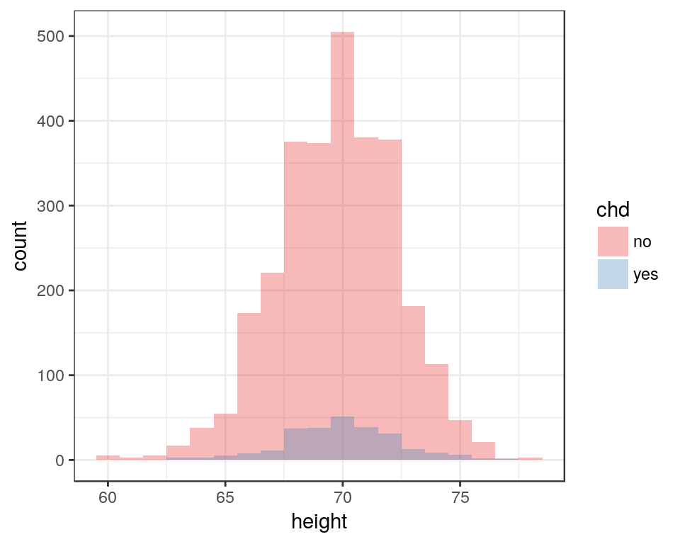

```r
ggplot(wcgs, aes(x=height, fill=chd)) +
  geom_histogram(binwidth=1, alpha = .3, position = 'identity') +
  scale_fill_brewer(palette = 'Set1')
```

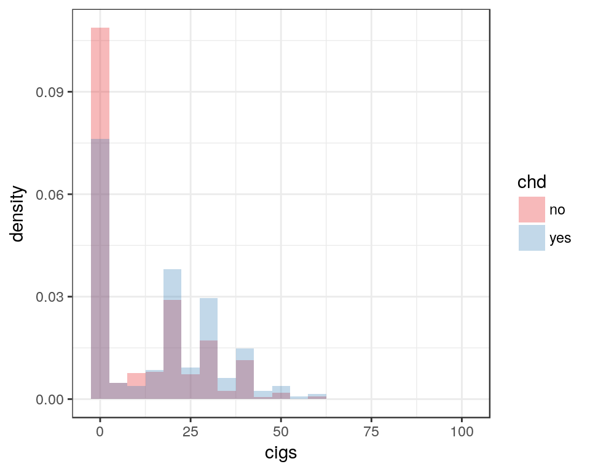

```r
ggplot(wcgs, aes(x=cigs, fill=chd)) +
  geom_histogram(position="identity", binwidth=5, alpha = .3,
                 aes(y=..density..)) +
  scale_fill_brewer(palette = 'Set1')
```

```r
lmod <- glm(chd ~ height + cigs, family = binomial, wcgs)
summary(lmod)
```

```
Call:
glm(formula = chd ~ height + cigs, family = binomial, data = wcgs)

Deviance Residuals:
    Min       1Q   Median       3Q      Max
-1.0041  -0.4425  -0.3630  -0.3499   2.4357

Coefficients:
            Estimate Std. Error z value Pr(>|z|)
(Intercept) -4.50161    1.84186  -2.444   0.0145 *
height       0.02521    0.02633   0.957   0.3383
cigs         0.02313    0.00404   5.724 1.04e-08 ***
---
Signif. codes:  0 '***' 0.001 '**' 0.01 '*' 0.05 '.' 0.1 ' ' 1

(Dispersion parameter for binomial family taken to be 1)

    Null deviance: 1781.2  on 3153  degrees of freedom
Residual deviance: 1749.0  on 3151  degrees of freedom
AIC: 1755

Number of Fisher Scoring iterations: 5
```

The model is:

$$\log \big( \frac{p}{1-p} \big) = \beta_0 + x_1 \beta_1 + x_2 \beta_2$$

**def** $\frac{p}{1-p}$ is the *odds ratio*

So we assume that the log odds ratio is a linear function of our predictors.

i.e. $\text{odds} = e^{\beta_0 + x_1 \beta_1 + x_2 \beta_2}$

So if $x_1$ increases by 1, on average, the log of the odds ratio increases by $\beta_1$ (or odss ratio increases by a factor of $\exp(\beta_1)$)

If $\beta_1 \approx 0$, then $\beta_1 \approx e^{\beta_1} - 1$

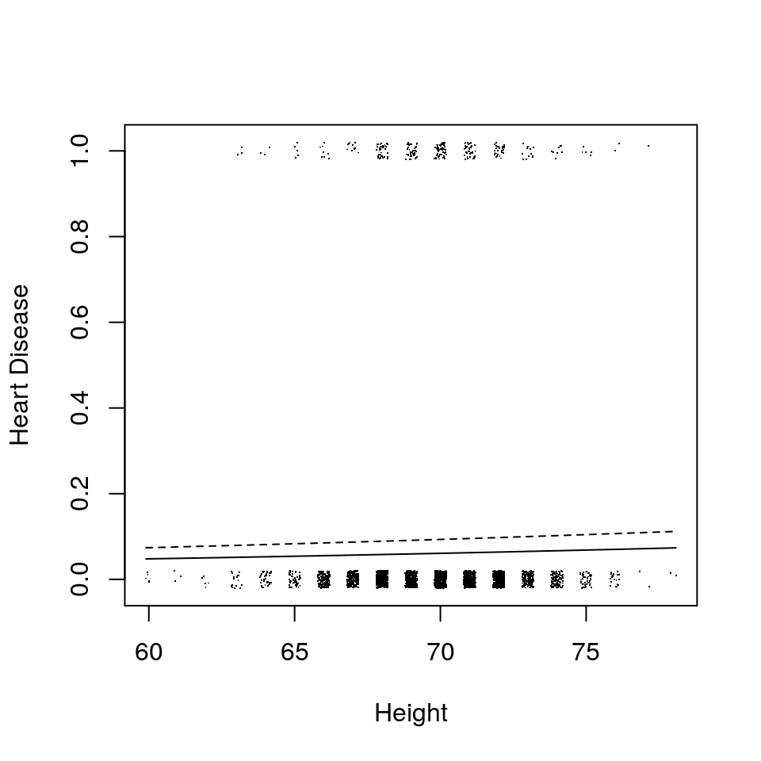

```r
wcgs$y <- ifelse(wcgs$chd == "no",0,1)
beta <- coef(lmod)
plot(jitter(y,0.1) ~ jitter(height), wcgs, xlab="Height", ylab="Heart Disease",pch=".")
curve(ilogit(beta[1] + beta[2]*x + beta[3]*0),add=TRUE)
curve(ilogit(beta[1] + beta[2]*x + beta[3]*20),add=TRUE,lty=2)
```

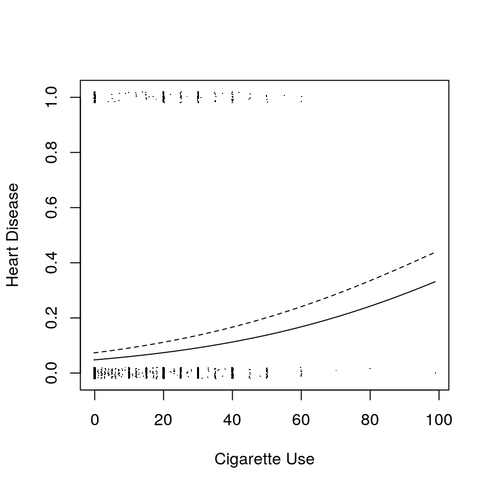

```r
plot(jitter(y,0.1) ~ jitter(cigs), wcgs, xlab="Cigarette Use", ylab="Heart Disease",pch=".")
curve(ilogit(beta[1] + beta[2]*60 + beta[3]*x),add=TRUE)
curve(ilogit(beta[1] + beta[2]*78 + beta[3]*x),add=TRUE,lty=2)
```

```r
exp(beta)
```

```
(Intercept)      height        cigs
 0.01109108  1.02552819  1.02339691
```

```r
#
exp(beta[3]*20)
```

```
    cigs
1.588115
```

**def** *Likelihood ratio statistic*

log-ratio of the larger model and smaller model

$$2 \log \frac{L_L}{L_S}$$

For deviance, the larger model is a saturated model. $\hat{p}_i = y_i$ for each $i = 1, 2, ..., n$

If $y_i = 1$ then $L_L(\beta) = 1$ or $l_L = 0$. Then the likelihood ratio statistic is $-2 \log L_S$ (i.e. *residual deviance*)

Another example: Perfect separation

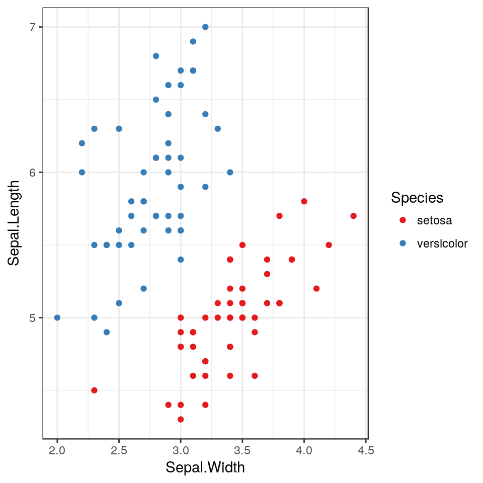

```r
iris.df <- iris %>%
  dplyr::filter(Species != 'virginica') %>%
  dplyr::select(Sepal.Width, Sepal.Length, Species)

ggplot(iris.df) +
  geom_point(aes(x = Sepal.Width, y = Sepal.Length, colour = Species)) +
  scale_colour_brewer(palette = 'Set1')
```

```r
iris.mod <- glm(Species ~ Sepal.Width + Sepal.Length, data = iris.df,
                family = binomial)
summary(iris.mod)
```

```
Call:
glm(formula = Species ~ Sepal.Width + Sepal.Length, family = binomial,
    data = iris.df)

Deviance Residuals:
       Min          1Q      Median          3Q         Max
-4.249e-05  -2.100e-08   0.000e+00   2.100e-08   4.522e-05

Coefficients:
             Estimate Std. Error z value Pr(>|z|)
(Intercept)    -360.6   195972.9  -0.002    0.999
Sepal.Width    -110.1    55361.5  -0.002    0.998
Sepal.Length    131.8    64577.0   0.002    0.998

(Dispersion parameter for binomial family taken to be 1)

    Null deviance: 1.3863e+02  on 99  degrees of freedom
Residual deviance: 7.1185e-09  on 97  degrees of freedom
AIC: 6

Number of Fisher Scoring iterations: 25
```

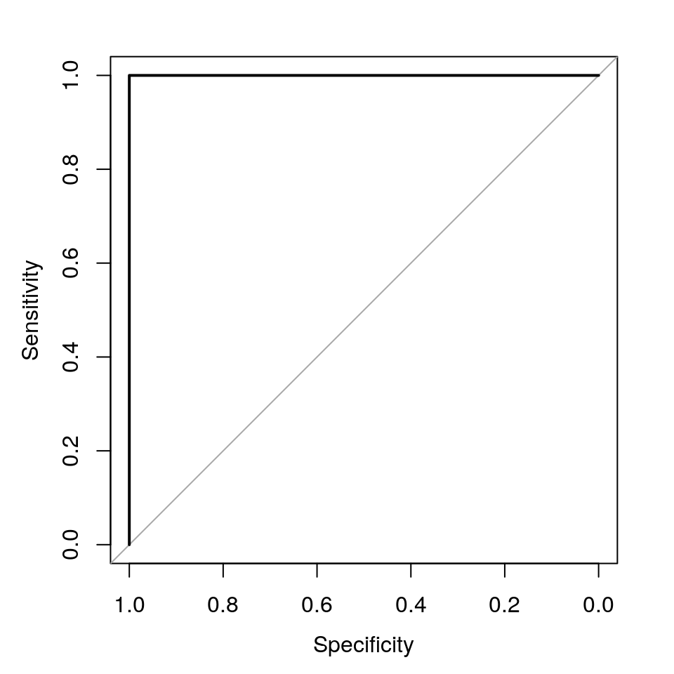

```r
plot(pROC::roc(iris.df$Species, predict(iris.mod, type = 'response')))
```

```r
library(brglm)

br.mod <- brglm(Species ~ Sepal.Width + Sepal.Length, data = iris.df,
                family = binomial)
summary(br.mod)
```

```
Call:
brglm(formula = Species ~ Sepal.Width + Sepal.Length, family = binomial,
    data = iris.df)


Coefficients:
             Estimate Std. Error z value Pr(>|z|)
(Intercept)   -24.508     12.493  -1.962  0.04979 *
Sepal.Width    -8.897      2.748  -3.237  0.00121 **
Sepal.Length    9.732      3.334   2.919  0.00351 **
---
Signif. codes:  0 '***' 0.001 '**' 0.01 '*' 0.05 '.' 0.1 ' ' 1

(Dispersion parameter for binomial family taken to be 1)

    Null deviance: 130.638  on 99  degrees of freedom
Residual deviance:   3.323  on 97  degrees of freedom
Penalized deviance: 6.60971
AIC:  9.323
```